# Varians

Ove Haugland Jakobsen

21 august 2016

## Exercise 3.3 (Optional)

In this exercise you will create some simulated data and will fit simple linear regression models to it. Make sure to use `set.seed(1)` prior to starting part (a) to ensure consistent results.

1. Using the `rnorm()` function, create a vector, `x`, containing 100 observations drawn from a $N(0,1)$ distribution. This represents a feature, `X`.
2. Using the `rnorm()` function, create a vector, `eps`, containing 100 observations drawn from a $N(0,0.25)$ distribution i.e. a normal distribution with mean zero and variance 0.25.

```r
set.seed(1)
x <- rnorm(100,0,1)
eps <- rnorm(100,0,0.25)
```

3. Using `x` and `eps`, generate a vector `y` according to the model
   $$Y = -1 + 0.5X + \epsilon$$
   What is the length of the vector `y`? What are the values of $\beta_0$ and $\beta_1$ in this linear model?

```r
y <- -1 + (0.5 * x) + eps
```

4. Create a scatterplot displaying the relationship between `x` and `y`. Comment on what you observe.

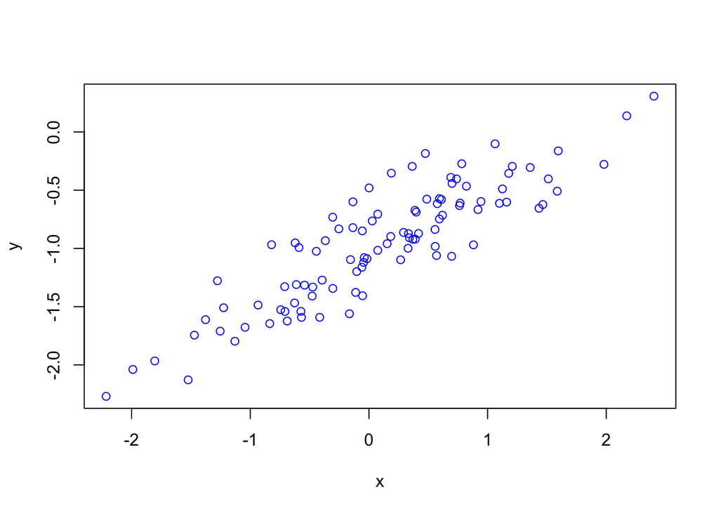

```r
par(mfrow=c(1,1))
plot(x, y, col="blue")
```

5. Fit a least squares linear model to predict `y` using `x`. Comment on the model obtained. How do $\hat{\beta}_0$ and $\hat{\beta}_1$ compare to $\beta_0$ and $\beta_1$?

```r
ols <- lm(y~x)
summary(ols)
```

```
##
## Call:
## lm(formula = y ~ x)
##
## Residuals:
##      Min       1Q   Median       3Q      Max
## -0.46921 -0.15344 -0.03487  0.13485  0.58654
##
## Coefficients:
##             Estimate Std. Error t value Pr(>|t|)
## (Intercept) -1.00942    0.02425  -41.63   <2e-16 ***
## x            0.49973    0.02693   18.56   <2e-16 ***
## ---
## Signif. codes:  0 '***' 0.001 '**' 0.01 '*' 0.05 '.' 0.1 ' ' 1
##
## Residual standard error: 0.2407 on 98 degrees of freedom
## Multiple R-squared:  0.7784, Adjusted R-squared:  0.7762
## F-statistic: 344.3 on 1 and 98 DF,  p-value: < 2.2e-16
```

6. Display the least squares line on the scatterplot obtained in (d). Draw the population regression line on the plot, in a different color. Use the `legend()` command to create an appropriate legend.

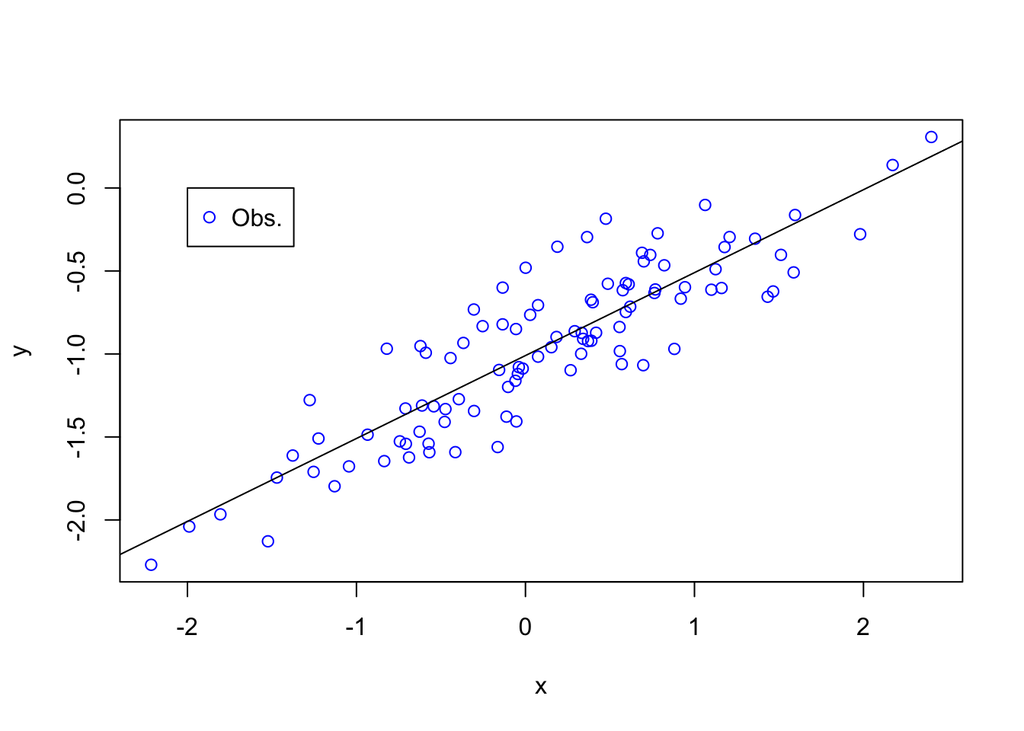

```r
plot(x, y, col="blue")
abline(lm(y~x))
legend(-2, 0,
       legend=c("Obs."),
       col=c("blue"),
       pch = 1)
```

7. Now fit a polynomial regression model that predicts $y$ using $x$ and $x^2$. Is there evidence that the quadratic term improves the model fit? Explain your answer.

```r
poly <- lm(y~x+I(x^2))
summary(poly)
```

```
##
## Call:
## lm(formula = y ~ x + I(x^2))
##
## Residuals:
##     Min      1Q  Median      3Q     Max
## -0.4913 -0.1563 -0.0322  0.1451  0.5675
##
## Coefficients:
##             Estimate Std. Error t value Pr(>|t|)
## (Intercept) -0.98582    0.02941 -33.516   <2e-16 ***
## x            0.50429    0.02700  18.680   <2e-16 ***
## I(x^2)      -0.02973    0.02119  -1.403    0.164
## ---
## Signif. codes:  0 '***' 0.001 '**' 0.01 '*' 0.05 '.' 0.1 ' ' 1
##
## Residual standard error: 0.2395 on 97 degrees of freedom
## Multiple R-squared:  0.7828, Adjusted R-squared:  0.7784
## F-statistic: 174.8 on 2 and 97 DF,  p-value: < 2.2e-16
```

**$R^2$ is the same, while the F-statistic is lower.**

8. Repeat (a)-(f) after modifying the data generation process in such a way that there is less noise in the data. The model should remain the same. You can do this by decreasing the variance of the normal distribution used to generate the error term $\epsilon$ in (b). Describe your results.

```r
x <- rnorm(100,0,1)
eps <- rnorm(100,0,0.05)
y <- -1 + (0.5 * x) + eps
plot(x,y)
clean.ols <- lm(y~x)
summary(clean.ols)
```

```
##
## Call:
## lm(formula = y ~ x)
##
## Residuals:
##       Min        1Q    Median        3Q       Max
## -0.137090 -0.028070 -0.000874  0.033987  0.092421
##
## Coefficients:
##              Estimate Std. Error t value Pr(>|t|)
## (Intercept) -0.997578   0.004955  -201.3   <2e-16 ***
## x            0.505311   0.004813   105.0   <2e-16 ***
## ---
## Signif. codes:  0 '***' 0.001 '**' 0.01 '*' 0.05 '.' 0.1 ' ' 1
##
## Residual standard error: 0.04953 on 98 degrees of freedom
## Multiple R-squared:  0.9912, Adjusted R-squared:  0.9911
## F-statistic: 1.102e+04 on 1 and 98 DF,  p-value: < 2.2e-16
```

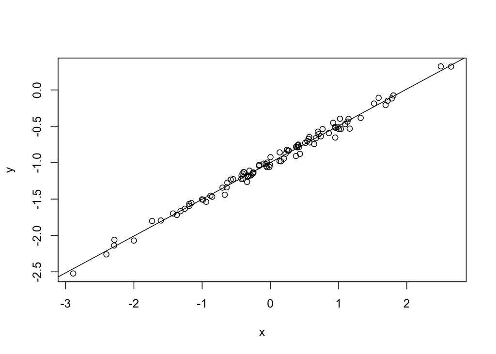

```r
abline(clean.ols)
```

**The model fit and explained variance of $Y$ is now much higher, as would be expected.**

1. Repeat (a)-(f) after modifying the data generation process in such a way that there is more noise in the data. The model should remain the same. You can do this by increasing the variance of the normal distribution used to generate the error term $\epsilon$ in (b). Describe your results.

```r
x <- rnorm(100,0,1)
eps <- rnorm(100,0,0.5)
y <- -1 + (0.5 * x) + eps
plot(x,y)
noisy.ols <- lm(y~x)
summary(noisy.ols)
```

```
##
## Call:
## lm(formula = y ~ x)
##
## Residuals:
##      Min       1Q   Median       3Q      Max
## -1.25507 -0.30275  0.01032  0.35241  1.04490
##
## Coefficients:
##             Estimate Std. Error t value Pr(>|t|)
## (Intercept) -1.02373    0.04838  -21.16   <2e-16 ***
## x            0.46253    0.04155   11.13   <2e-16 ***
## ---
## Signif. codes:  0 '***' 0.001 '**' 0.01 '*' 0.05 '.' 0.1 ' ' 1
##
## Residual standard error: 0.4835 on 98 degrees of freedom
## Multiple R-squared:  0.5584, Adjusted R-squared:  0.5539
## F-statistic: 123.9 on 1 and 98 DF,  p-value: < 2.2e-16
```

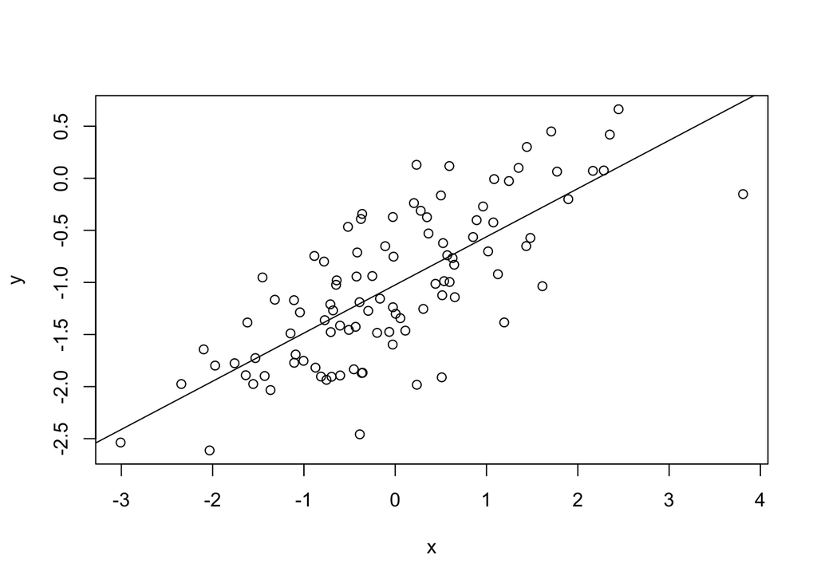

```r
abline(noisy.ols)
```

**The model fit and explained variance of $Y$ is now much lower, as would be expected.**